# Lecture 2 Exercises

## Short Questions

1. How do you check whether an element is part of a list?
2. How do you reference a global variable in `.query()`?

```python
# Write your answers here as comments:

# 1.    To check if an element is part of a list you can use the 'in' command. E.g. with a list called 'values' and a
#       target value called 'target', you can say 'target in values' which will return True if the target is in the list
#       of values and False if not.
# 2.    To reference a global variable in query you use the '@' symbol before the variable name. E.g. '@variable'.
```

## Long Questions

Import the pandas and matplotlib packages

```python
# Write your own code

import pandas as pd
import matplotlib.pyplot as plt
```

(a) Checking a string condition

- Define a variable "fruit" with the value "apple"
- Define a list

list_fruits = ["banana","orange","apple"]

- Write an expression to test whether "fruit" is contained in "list_fruits"

Hint: Use the "in" command. The final output should be True/False.

To get full points run all of the above commands

```python
# Write your own code

fruit = "apple"
list_fruits = ["banana", "orange", "apple"]
print (fruit in list_fruits)
```

```
True
```

(b) Classifying a variable

- Define a new variable "year" an assign the value "2008"
- Write an if/else statement that does the following
  - print("Year 2000 or earlier") if the year is less than or equal to 2000.
  - print("Between 2001 and 2005") if the year is between 2001 and 2005.
  - print("Year 2006 or later") if the year is after 2005.

To get full points you must do all of the above instructions

```python
# Write your own code

year = 2008

if ( year <= 2000):
    print ("Year 2000 or earlier")
elif ((year >= 2001) & (year <= 2005)):
    print ("Between 2001 and 2005")
else:
    print ("Year 2006 or later")
```

```
Year 2006 or later
```

(c) Split a dataset into subsets

- Import the "features.csv" file as a pandas dataframe called "data"
- Create `list_status = [0,1]`
- Create `list_prob = [0.5, 0.5]`
- Create a new variable $n = 1000$ with the number of rows of the dataset
- Use

```
    np.random.choice(list_status,
                     size = n,
                     p = list_prob)
```

$\qquad$ to create a new column called "status"  
$\qquad$ which randomly assigns each row to "0" or "1"  
$\qquad$ with equal probability

- Use .query() to subset all observations with status == 0.  
  store it in a new dataset called "data0"
- Use .query() to subset all observations with status == 1.  
  store it in a new dataset called "data1"

```python
# Write your own code

import numpy as np

data = pd.read_csv('data_raw/features.csv')
list_status = [0,1]
list_prob = [0.5, 0.5]

# Create n = number of rows in dataset
n = len(data)

data['status'] = np.random.choice(
    list_status,
    size = n,
    p = list_prob
)

data0 = data.query('status == 0')
data1 = data.query('status == 1')
```

For questions (d) through (f) mport the dataset  
"data_raw/fifa23_players_basic.csv"

- It's a dataset on professional soccer players
- Rows correspond to players (18,539)
- Columns contain attributes of players (32)
- Try to view the dataset before starting

```python
# Write your own code

football_dataset = pd.read_csv('data_raw/fifa23_players_basic.csv')
```

(d) Create a new dataset subsetting the  
players whose age is less than 20

```python
# Write your own code

youth_players = football_dataset.query('Age < 20')
```

(e) Use queries + global variables

- Compute the mean of the column "Value(in Euro)"  
  and store it as a variable
- Subset the players whose value is above the mean value  
  using ".query()"

HINT: Remember that there is a special syntax for  
when the column names have spaces (see Lecture 10)  
Reference the column as `` `Value(in Euro)` `` inside .query()

```python
# Write your own code

mean_euro = np.mean(football_dataset['Value(in Euro)'])
players_above_mean_euro = football_dataset.query('`Value(in Euro)` > @mean_euro')
```

(f) Use sorting + ".iloc[]"

- Use ".sort_values()" to order the "Age" column  
  from youngest to oldest
- Get a subset with the 5 youngest players

```python
# Write your own code

players_sorted = football_dataset.sort_values(by = "Age", ascending = True)
youngest_players = players_sorted.iloc[0:5,:]
```

For questions (h)-(i), read "data_raw/wdi_2020.csv"  
This is a dataset of countries from  
the World Development Indicators

(g) Extract sorted elements from a dataset

- Sort by "prop_urbanpopulation" in descending order
- Subset the 5 countries with the highest urban population

```python
# Write your own code

development_data = pd.read_csv('data_raw/wdi_2020.csv')
development_data.sort_values(by = 'prop_urbanpopulation', ascending = False)
highest_population = development_data.iloc[0:5,:]
```

(h) Subset elements with query

- Compute the median of "prop_urbanpopulation"
- Use ".query()" to subset countries with  
  "prop_urbanpopulation" above the median

```python
# Write your own code

median_pop = np.nanmedian(development_data['prop_urbanpopulation']) #nanmedium to ignore rows with missing values
above_median = development_data.query('prop_urbanpopulation > @median_pop')
```

(i) Plot by category

- Read "data_raw/wdi_urban.csv"  
  This contains data from 1980 and 2020
- Create a list with the unique values of "year"
- Create a plot with a ...
  - Histogram of "prop_urbanpopulation"  
    for each year
  - Set the histogram option `alpha = 0.5` for transparency
  - All the histograms should be overlapping
  - Create a legend with the list of years
  - Label the axes and the title

What do we learn from the graph?

HINT: See the example at the end of Lecture 10

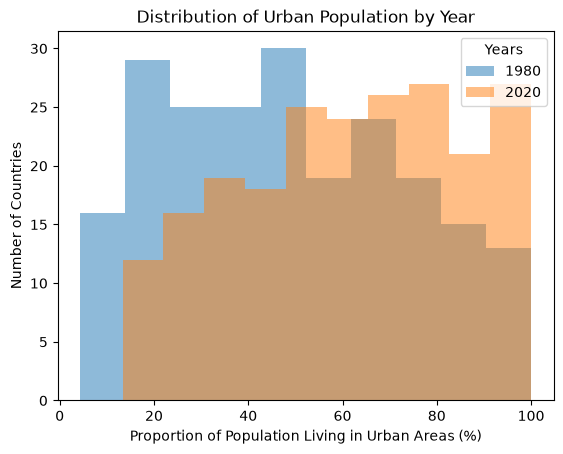

```python
# Write your own code

urban_data = pd.read_csv('data_raw/wdi_urban.csv')

# Compute number of unique years
unique_years = pd.unique(urban_data['year'])

# Use a for loop to plot a histogram for each year.
# Each plot will have a different color
for year in unique_years:
    df = urban_data.query("year == @year")
    plt.hist(df['prop_urbanpopulation'], alpha = 0.5)

plt.xlabel('Proportion of Population Living in Urban Areas (%)')
plt.ylabel('Number of Countries')
plt.legend(labels = unique_years,
           title = "Years")
plt.title('Distribution of Urban Population by Year')
plt.show()
```

# Review of last lecture

(k) Composite operations on arrays

- Define $r = 0.04$
- Define two arrays $A$ and $T$ using "np.array()", assigning the following values

$ a = \begin{pmatrix} a_0 \\ a_1 \\ a_2 \end{pmatrix} = \begin{pmatrix} 20 \\ 30 \\ 15 \end{pmatrix}, \qquad t = \begin{pmatrix} t_0 \\ t_1 \\ t_2 \end{pmatrix} = \begin{pmatrix} 0 \\ 1 \\ 2 \end{pmatrix} $

- Use element-by-element vector operations to compute a new array $M$ of length 3:

$ M = \begin{pmatrix} a_1 / (1+r)^{t_0} \\ a_2 / (1+r)^{t_1} \\ a_3 / (1+r)^{t_2} \end{pmatrix} $

- Compute the sum of the values of $M$ using "M.sum()"

Note: I am using subscripts to denote the individual elements of $a$ and $t$.

- In the code just enter the values of $a$ and $t$.
- To get full points you must do all of the above tasks

```python
# Write your own code

r = 0.04
A = np.array([20, 30, 15])
T = np.array([0, 1, 2])

M = A / (1 + r)**T
M_sum = M.sum()

M_sum
```

```
np.float64(62.71449704142012)
```